# GRAPH Workshop: Universaltool Regression

Sitzung 3

2021-12-02

# Datensatz: Übersterblichkeit

## Wiederholung: Deskriptiv- und Inferenzstatistik der multiplen Regression

Aus aktuellem Anlass: Bitte lest Sie diese “Analyse” und kritisiert die Anwendbarkeit der Regressionsmodellierung anhand eures reichhaltigen Vorwissens aus den letzten beiden Sitzungen 😉 (zur journalistischen Aufarbeitung siehe z.B. [hier](https://www.heise.de/tp/features/Forencheck-Niedrige-Uebersterblichkeit-in-Sachsen-Impfquote-in-Afrika-und-der-Begriff-der-Immunitaet-6279279.html)

# Datensatz: kidiq

In Kapitel 3 (siehe moodle) aus Gelman & Hill (2006) wird in Abbildung 3.2. der Testrohwert eines Intelligenztest von Kindern `kid_score` mit dem IQ-Wert der Mütter `mom_iq` prädiziert. Ihr könnt die zugehörigen Daten mit der folgenden Syntax importieren

```r
library(tidyverse)
data_kidiq <- read_delim("https://raw.githubusercontent.com/sammerk/did_data/master/kidiq.csv")
```

JASP, jamovi und SPSS-Nutzer*innen können den Datensatz hier herunterladen.

## Übung: Deskriptiv- und Inferenzstatistik der multiplen Regression (kidiq)

> AA: Bitte prädiziert `kid_score` mit `mom_iq`, berechnet Effektstärken und Inferenzstatistiken und prüft, inwiefern Ihr die Annahmen dieser für hinreichend erfüllt anseht.

### Regression `kid_score ~ mom_iq`

Die Syntax für ein nicht-standardisiertes Modell:

```r
lm(kid_score ~ mom_iq, data = data_kidiq)
```

```
##
## Call:
## lm(formula = kid_score ~ mom_iq, data = data_kidiq)
##
## Coefficients:
## (Intercept)       mom_iq
##       25.80         0.61
```

Da die Daten keine missings enthalten, kann man direkt in dere “formula” `scale()` für die Standardisierung anwenden und erhält via `summary()` auch $R^2$ und p-Werte für $\beta_i$ und $R^2$.

```r
mod_kidiq_1 <- lm(scale(kid_score) ~ scale(mom_iq), data = data_kidiq)
summary(mod_kidiq_1)
```

```
##
## Call:
## lm(formula = scale(kid_score) ~ scale(mom_iq), data = data_kidiq)
##
## Residuals:
##     Min      1Q  Median      3Q     Max
## -2.7805 -0.5916  0.1086  0.5737  2.3366
##
## Coefficients:
##                 Estimate Std. Error t value Pr(>|t|)
## (Intercept)   -5.068e-16  4.296e-02    0.00        1
## scale(mom_iq)  4.483e-01  4.301e-02   10.42   <2e-16 ***
## ---
## Signif. codes:  0 '***' 0.001 '**' 0.01 '*' 0.05 '.' 0.1 ' ' 1
##
## Residual standard error: 0.8949 on 432 degrees of freedom
## Multiple R-squared:  0.201,  Adjusted R-squared:  0.1991
## F-statistic: 108.6 on 1 and 432 DF,  p-value: < 2.2e-16
```

Mit $\beta_1 = .4$ haben wir einen moderaten bis starken Effekt nach Cohen (1988), der p-Wert ist < .05. Auch der $BF_{10}$ zeigt sehr starke relative Evidenz für das Modell mit Prädiktor:

```r
library(BayesFactor)
lmBF(formula = kid_score ~ mom_iq, data = data_kidiq)
```

```
## Bayes factor analysis
## --------------
## [1] mom_iq : 4.516119e+19 ±0%
##
## Against denominator:
##   Intercept only
## ---
## Bayes factor type: BFlinearModel, JZS
```

### Regressionsdiagnostik

```r
library(hrbrthemes)
```

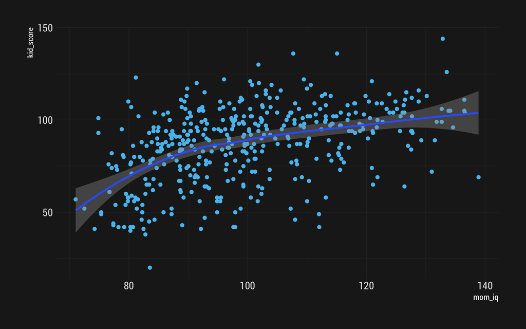

```r
ggplot(data_kidiq, aes(mom_iq, kid_score)) +
  geom_point() +
  stat_smooth() +
  theme_modern_rc()
```

### Annahmen

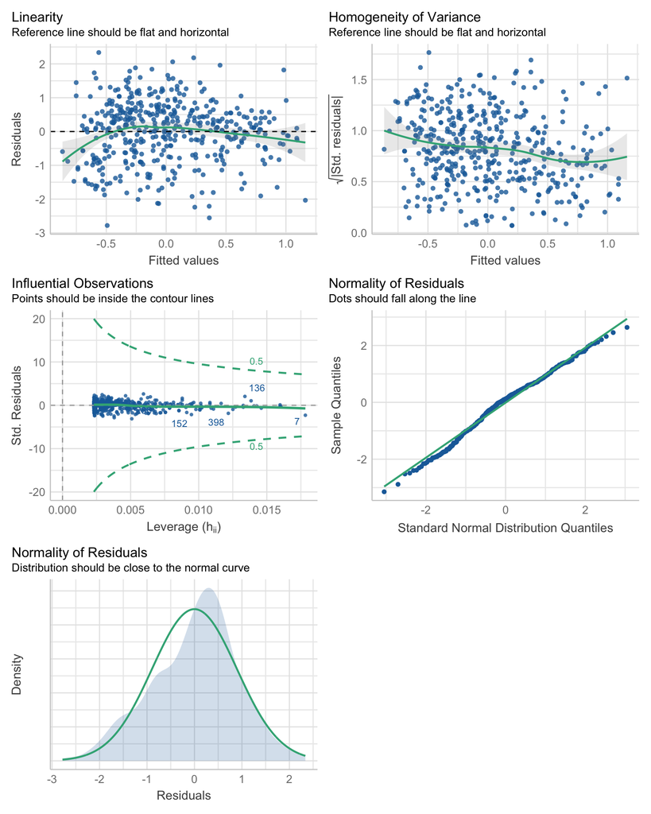

```r
library(performance)
check_model(mod_kidiq_1)
```

# Datensatz: weightloss

Der Datensatz kann wieder wie folgt nach R importiert werden

```r
data_weightloss <-
  read.csv("https://stats.idre.ucla.edu/wp-content/uploads/2019/03/exercise.csv") %>%
  mutate(prog = factor(prog, labels = c("jog", "swim", "read")),
         gender = factor(gender, labels = c("male", "female")))
```

bzw. hier als `.sav` heruntergeladen werden.

Die Variablen im Datensatz [hier geklaut](https://stats.idre.ucla.edu/r/seminars/interactions-r/#top) sind die folgenden:

- loss: weight loss (continuous), positive = weight loss, negative scores = weight gain
- hours: hours spent exercising (continuous)
- effort: effort during exercise (continuous), 0 = minimal physical effort and 50 = maximum effort
- prog: exercise program (categorical)
  - jogging=1
  - swimming=2
  - reading=3
- gender: participant gender (binary)
  - male=1
  - female=2

## Moderation/Interaktion nominal-metrisch (weightloss)

```r
lm(loss ~ hours * gender, data = data_weightloss) %>%
  summary()
```

```
##
## Call:
## lm(formula = loss ~ hours * gender, data = data_weightloss)
##
## Residuals:
##     Min      1Q  Median      3Q     Max
## -27.118 -11.350  -1.963  10.001  42.376
##
## Coefficients:
##                    Estimate Std. Error t value Pr(>|t|)
## (Intercept)           6.906      2.805   2.462    0.014 *
## hours                 1.591      1.352   1.177    0.240
## genderfemale         -3.571      3.915  -0.912    0.362
## hours:genderfemale    1.724      1.898   0.908    0.364
## ---
## Signif. codes:  0 '***' 0.001 '**' 0.01 '*' 0.05 '.' 0.1 ' ' 1
##
## Residual standard error: 14.06 on 896 degrees of freedom
## Multiple R-squared:  0.008433,   Adjusted R-squared:  0.005113
## F-statistic:  2.54 on 3 and 896 DF,  p-value: 0.05523
```

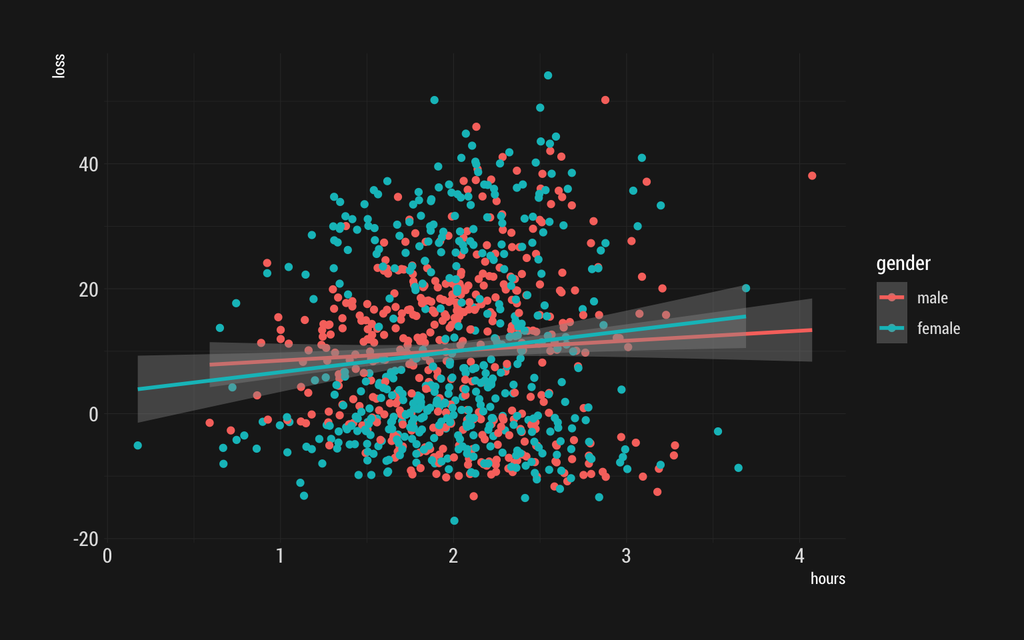

```r
ggplot(data_weightloss, aes(hours, loss, color = gender)) +
  geom_point() +
  stat_smooth(method = "lm") +
  theme_modern_rc()
```

## Moderation/Interaktion metrisch-metrisch (weightloss)

```r
lm(scale(loss) ~ scale(hours) * scale(effort), data = data_weightloss) %>%
  summary()
```

```
##
## Call:
## lm(formula = scale(loss) ~ scale(hours) * scale(effort), data = data_weightloss)
##
## Residuals:
##     Min      1Q  Median      3Q     Max
## -2.0932 -0.7517 -0.1262  0.7892  2.4471
##
## Coefficients:
##                             Estimate Std. Error t value Pr(>|t|)
## (Intercept)                -0.001154   0.032062  -0.036   0.9713
## scale(hours)                0.080341   0.032095   2.503   0.0125 *
## scale(effort)               0.257996   0.032082   8.042 2.79e-15 ***
## scale(hours):scale(effort)  0.070949   0.033821   2.098   0.0362 *
## ---
## Signif. codes:  0 '***' 0.001 '**' 0.01 '*' 0.05 '.' 0.1 ' ' 1
##
## Residual standard error: 0.9617 on 896 degrees of freedom
## Multiple R-squared:  0.07818,    Adjusted R-squared:  0.07509
## F-statistic: 25.33 on 3 and 896 DF,  p-value: 9.826e-16
```

### Grafische Darstellung

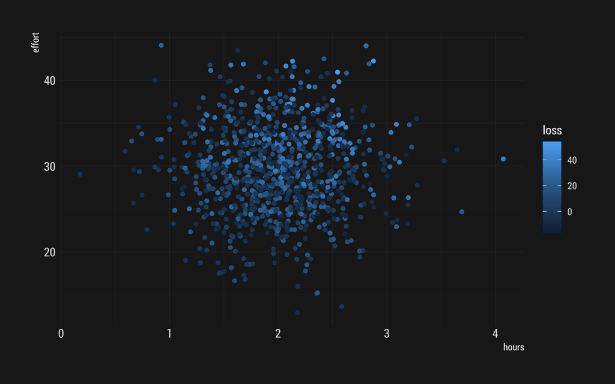

```r
ggplot(data_weightloss, aes(hours, effort, color = loss)) +
  geom_point() +
  theme_modern_rc()
```